# Taylor Swift

This week’s data: Taylor Swift.

### Get the data

```r
beyonce_lyrics <- readr::read_csv('https://raw.githubusercontent.com/rfordatascience/tidytuesday/master/data/2020/2020-09-29/beyonce_lyrics.csv')
taylor_swift_lyrics <- readr::read_csv('https://raw.githubusercontent.com/rfordatascience/tidytuesday/master/data/2020/2020-09-29/taylor_swift_lyrics.csv')
sales <- readr::read_csv('https://raw.githubusercontent.com/rfordatascience/tidytuesday/master/data/2020/2020-09-29/sales.csv')
charts <- readr::read_csv('https://raw.githubusercontent.com/rfordatascience/tidytuesday/master/data/2020/2020-09-29/charts.csv')
```

It looks like there are four datasets. (1) Beyonce lyrics, (2) Taylor Swift lyrics, (3) sales, and (4) charts.

I don’t have any particular inspiration for this graphic. I don’t like sentiment analysis of lyrics because the sentiment is heavily weighted towards songs with more (and more repetitive) lyrics. There are a host of problems with sentiment analysis that I don’t know how to solve, too. What about negations? Does ‘not happy’ count as positive, negative, or neutral? I’m just not good enough at natural language processing yet.

So, barring that I have to stick with a simpler linguistic analysis, or something that integrates other data. Let’s get a feeling for the other data sets.

```r
charts %>%
  skimr::skim()
```

```
-- Data Summary ------------------------
                           Values
Name                       Piped data
Number of rows             130
Number of columns          8
_______________________
Column type frequency:
  character                8
________________________
Group variables            None

-- Variable type: character -------------------------------------------------
# A tibble: 8 x 8
  skim_variable  n_missing complete_rate   min   max empty n_unique
* <chr>              <int>         <dbl> <int> <int> <int>    <int>
1 artist                 0         1         7    12     0        2
2 title                  0         1         1    20     0       13
3 released               0         1        13    26     0       13
4 re_release           110         0.154    18    20     0        2
5 label                  0         1         8    26     0        6
6 formats                0         1        20    76     0        8
7 chart                  0         1         2     3     0       10
8 chart_position         0         1         1     2     0       28
  whitespace
*      <int>
1          0
2          0
3          0
4          0
5          0
6          0
7          0
8          0
```

So, these are all characters right now, but I think chart_position is just a normal ranking. Let me see if I can clean it up at all. Convert date variables to date-time format. For ranking, replace “—” with "".

```r
charts_clean <- charts %>%
  mutate(
    chart_position = as.integer(gsub("—", "", chart_position)),
    released_date = gsub(" \\(US\\)\\[51\\]", "", released),
    released_date = gsub("June 23, 2003 \\(UK\\)\\[39\\]",
                    "June 23, 2003", released_date),
    released_date = lubridate::mdy(released_date)
  ) %>%
  select(artist, title, released, released_date, everything())
```

The unit of observation here is the artist/album/country. How can I visualize this, then? See notebook, first page.

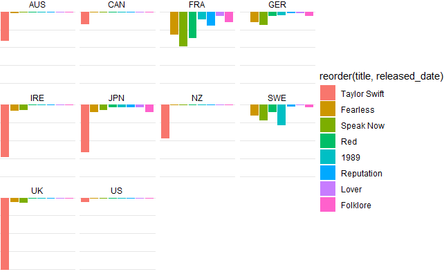

I really like this actually. I think this might be a good rough design. There’s one other type of graphic I want to explore, having to do with concentric circles. But that graphic is better suited to segmented populations where you want to show each data point inside a circle. It’s also not clear how I would put each data point in its circle… Probably with a polar coordinate system, then it shouldn’t be too hard. Okay, I won’t use it, but for the experiment I’ll generate a usable dataset.

Alternatively, I could put each point into a circle where the size of the circle is mapped to the population of the country. But what points would go in each circle? Agh. But it’s an interesting idea. I want to explore it further.

```r
df <- data.frame(
  x = runif(n = 50, min = 0, max = 1),
  y = runif(n = 50, min = 1, max = 10)
) %>%
  mutate(
    group = case_when(
      y <= 6 ~ 'one',
      y > 6 & y <= 9 ~ 'two',
      y > 9 ~ 'three'
      ),
    group = factor(group)
    )

df %>%
  ggplot() + geom_point(aes(x = x, y=y, color = group)) +
  coord_polar() +
  scale_y_continuous(breaks = c(6, 9, 10)) +
  theme_void() +
  theme(
    panel.grid.major.y = element_line(color = grey(0.8), linetype = 'solid')
  )
```

[output not shown]